# Introdução ao R - Sessão 5 e 6

### SStotal (SSt)

Este indicador avalia em que medida a média (enquanto modelo mais simples que pode ser estimado) estima bem os dados observados de Y.

> a fórmula do SSt é igual ao numerador da fórmula usada para calcular a variância.

Este modelo mais simples é usado para comparar com o modelo produzido no procedimentos de OLS e verificar a sua pertinência na explicação de Y.

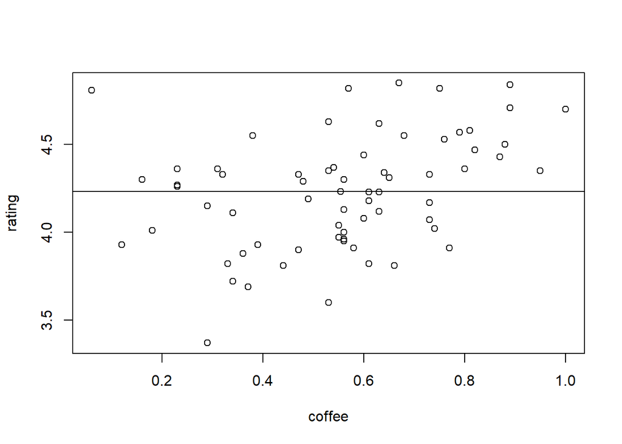

```r
plot(rating ~ coffee, data = coffee)
abline(h=mean(coffee$rating))
```

### SSresidual (SSr)

Este indicador avalia em que medida o modelo de regressão estimado com os nossos preditores representa bem os dados observados. É calculada pela soma dos quadrados das diferenças entre os valores observados de y e os valores estimados de Y pelo modelo)

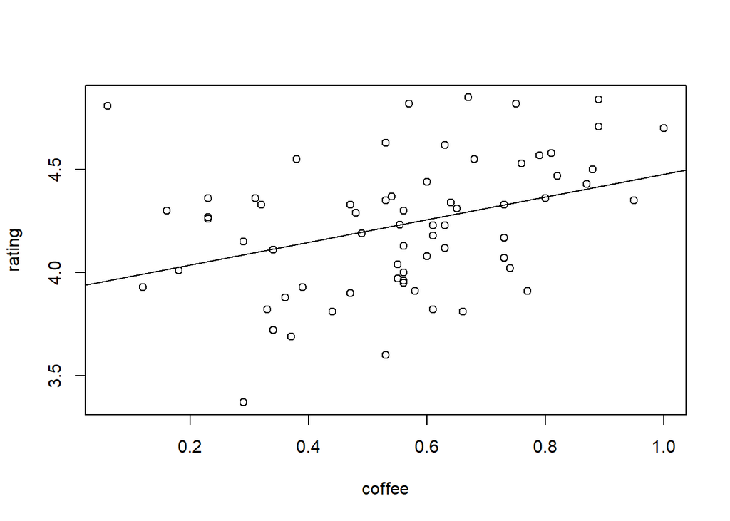

```r
plot(rating ~ coffee, data = coffee)
abline(lm(rating ~ coffee, data = coffee))
```

### SSmodel (SSm)

Este indicador compara em que medida o modelo de regressão estimado representa melhor dados observados relativamente ao modelo mais simples (a média). Na prática este indicador é a diferença entre SSt e SSr

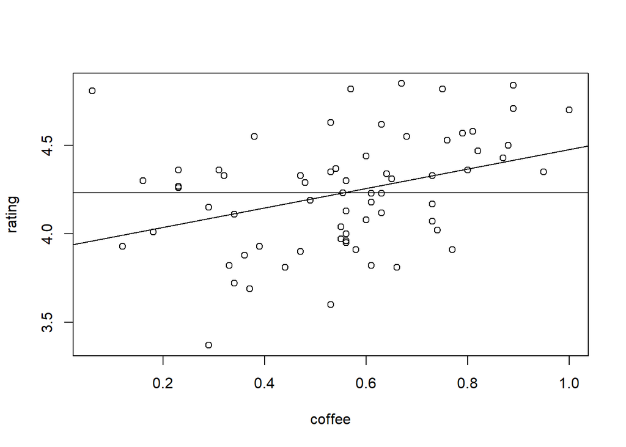

```r
plot(rating ~ coffee, data = coffee)
abline(h=mean(coffee$rating))
abline(lm(rating ~ coffee, data = coffee))
```

### Calculando SStotal, a SStotal e SSmodel passo a passo

A função anova() permite obter os SSresidual e SSmodel automaticamente no R.

```r
anova(model1) # To get the sums of squares and mean squares
```

```
## Analysis of Variance Table
##
## Response: rating
##           Df Sum Sq Mean Sq F value   Pr(>F)
## coffee     1 0.9102 0.91020  9.7865 0.002631 **
## Residuals 65 6.0454 0.09301
## ---
## Signif. codes:  0 '***' 0.001 '**' 0.01 '*' 0.05 '.' 0.1 ' ' 1
```

De seguida explicamos mais detalhadamente os procedimentos envolvidos no cálculo destes indicadores.

```r
# SStotal
coffee$rating
```

```
##  [1] 4.85000 4.84000 4.82000 4.82000 4.81000 4.71000 4.70000 4.63000 4.62000
## [10] 4.58000 4.57000 4.55000 4.55000 4.53000 4.50000 4.47000 4.44000 4.43000
## [19] 4.37000 4.36000 4.36000 4.36000 4.35000 4.35000 4.34000 4.33000 4.33000
## [28] 4.33000 4.31000 4.30000 4.30000 4.29000 4.27000 4.26000 4.23000 4.23000
## [37] 4.19000 4.18000 4.17000 4.15000 4.13000 4.12000 4.11000 4.08000 4.07000
## [46] 4.04000 4.02000 4.01000 4.00000 3.97000 3.96000 3.95000 3.93000 3.93000
## [55] 3.91000 3.91000 3.90000 3.88000 3.82000 3.82000 3.81000 3.81000 3.72000
## [64] 3.69000 3.60000 3.37000 4.23264
```

```r
mean(coffee$rating)
```

```
## [1] 4.232427
```

```r
SSt <- sum((coffee$rating - mean(coffee$rating))^2) # numerador da fórmula da variância
SSt
```

```
## [1] 6.955612
```

```r
# SSresidual
sum(residuals(model1)) # it is guaranteed by the least squares fitting procedure that the sum of the residuals is zero.
```

```
## [1] -1.179612e-15
```

```r
sum(residuals(model1)^2) # mean squared error (MSE) is the sum of the square of the residuals
```

```
## [1] 6.045408
```

```r
coffee$rating
```

```
##  [1] 4.85000 4.84000 4.82000 4.82000 4.81000 4.71000 4.70000 4.63000 4.62000
## [10] 4.58000 4.57000 4.55000 4.55000 4.53000 4.50000 4.47000 4.44000 4.43000
## [19] 4.37000 4.36000 4.36000 4.36000 4.35000 4.35000 4.34000 4.33000 4.33000
## [28] 4.33000 4.31000 4.30000 4.30000 4.29000 4.27000 4.26000 4.23000 4.23000
## [37] 4.19000 4.18000 4.17000 4.15000 4.13000 4.12000 4.11000 4.08000 4.07000
## [46] 4.04000 4.02000 4.01000 4.00000 3.97000 3.96000 3.95000 3.93000 3.93000
## [55] 3.91000 3.91000 3.90000 3.88000 3.82000 3.82000 3.81000 3.81000 3.72000
## [64] 3.69000 3.60000 3.37000 4.23264
```

```r
fitted(model1)
```

```
##        1        2        3        4        5        6        7        8
## 4.296216 4.417606 4.241039 4.340358 3.959634 4.417606 4.478301 4.218968
##        9       10       11       12       13       14       15       16
## 4.274145 4.373464 4.362429 4.136202 4.301734 4.345876 4.412088 4.378982
##       17       18       19       20       21       22       23       24
## 4.257592 4.406571 4.224485 4.367946 4.053435 4.097577 4.450713 4.218968
##       25       26       27       28       29       30       31       32
## 4.279663 4.185861 4.103095 4.329322 4.285180 4.014811 4.235521 4.191379
##       33       34       35       36       37       38       39       40
## 4.053435 4.053435 4.263109 4.274145 4.196897 4.263109 4.329322 4.086542
##       41       42       43       44       45       46       47       48
## 4.235521 4.274145 4.114131 4.257592 4.329322 4.230003 4.334840 4.025847
##       49       50       51       52       53       54       55       56
## 4.235521 4.230003 4.235521 4.235521 4.141719 3.992740 4.351393 4.246556
##       57       58       59       60       61       62       63       64
## 4.185861 4.125166 4.263109 4.108613 4.290698 4.169308 4.114131 4.130684
##       65       66       67
## 4.218968 4.086542 4.232424
```

```r
SSr <- sum((coffee$rating - fitted(model1))^2) # Sum of the squared residuals
SSr
```

```
## [1] 6.045408
```

```r
# OR
residuals(model1)
```

```
##             1             2             3             4             5
##  0.5537841039  0.4223938824  0.5789614773  0.4796422052  0.8503660818
##             6             7             8             9            10
##  0.2923938824  0.2216987716  0.4110324267  0.3458550533  0.2065357811
##            11            12            13            14            15
##  0.2075712558  0.4137984869  0.2482663666  0.1841244678  0.0879116197
##            16            17            18            19            20
##  0.0910180438  0.1824082653  0.0234293570  0.1455146894 -0.0079464816
##            21            22            23            24            25
##  0.3065645470  0.2624226483 -0.1007125417  0.1310324267  0.0603373159
##            26            27            28            29            30
##  0.1441388508  0.2269049109  0.0006776799  0.0248195786  0.2851887084
##            31            32            33            34            35
##  0.0644792147  0.0986211134  0.2165645470  0.2065645470 -0.0331094720
##            36            37            38            39            40
## -0.0441449467 -0.0068966239 -0.0831094720 -0.1593223201  0.0634581229
##            41            42            43            44            45
## -0.1055207853 -0.1541449467 -0.0041305638 -0.1775917347 -0.2593223201
##            46            47            48            49            50
## -0.1900030480 -0.3148400575 -0.0158467663 -0.2355207853 -0.2600030480
##            51            52            53            54            55
## -0.2755207853 -0.2855207853 -0.2117192505 -0.0627403422 -0.4413932695
##            56            57            58            59            60
## -0.3365562600 -0.2858611492 -0.2451660385 -0.4431094720 -0.2886128264
##            61            62            63            64            65
## -0.4806981587 -0.3593079372 -0.3941305638 -0.4406837758 -0.6189675733
##            66            67
## -0.7165418771  0.0002155492
```

```r
SSr <- sum(residuals(model1)^2)
SSr
```

```
## [1] 6.045408
```

```r
# SSmodel
SSm <- SSt - SSr
SSm
```

```
## [1] 0.9102043
```

A média destes indicadores é obtida com base nos graus de liberdade respetivos.

```r
# Calculate degrees of freedom (total, residual and model)
n <- length(coffee$coffee)
model1$coef
```

```
## (Intercept)      coffee
##   3.9265275   0.5517737
```

```r
k <- length(model1$coef) # k = model parameter: b0, b1
(df.total <- n-1)
```

```
## [1] 66
```

```r
(df.residual <- n-k)
```

```
## [1] 65
```

```r
(df.model <- k-1)
```

```
## [1] 1
```

```r
# Calculate mean squares - these values are just variances
(ms.residual <- SSr/df.residual)
```

```
## [1] 0.09300628
```

```r
(ms.model<- SSm/df.model)
```

```
## [1] 0.9102043
```

### Avaliação da qualidade do modelo

Como dito anteriormente, a estimação por OLS garante que a média dos resíduos é zero. Por isso, foi necessário anteriormente fazer a soma dos **quadrados** desses mesmos resíduos (SSr). Por conseguinte, para ter uma valor interpretável, faz mais sentido calcular a raiz quadrada da média dos quadrados dos resíduos. O R denomina este indicador de residual standard error (RSE). Assim, o valor do RSE pode ser calculado pela raiz quadrada da média dos quadrados dos resíduos (SSr). O RSE pode ser visto como o desvio padrão dos resíduos. Consiste numa estimativa do desvio ou erro médio presente na predição feita pelo modelo. Mais concretamente, o RSE é uma estimativa do desvio padrão do parâmetro ε do modelo. O RSE é vista como uma medida da qualidade do modelo, uma vez que avalia a distância média entre os valores preditos e os valores observados da VD.

```r
# Calculate residual standard error
(RSE <- sqrt(ms.residual))
```

```
## [1] 0.3049693
```

No exemplo anterior, o valor observado do rating geral do café desvia-se em média cerca de .305 do valor estimado pelo nosso modelo.

```r
mean(coffee$rating)
```

```
## [1] 4.232427
```

```r
RSE
```

```
## [1] 0.3049693
```

```r
RSE/mean(coffee$rating)
```

```
## [1] 0.07205541
```

Por outras palavras, considerando que a média dos ratings para todos os cafés é de cerca 4.23 e que o RSE é de .305, podemos dizer que a percentagem de erros da nossa estimativa é de cerca de 7%. Ainda no casos do nosso modelo, os graus de liberdade para cálculo do RSE são iguais ao n da nossa amostra (67) menos os parametros estimados pelo modelo (2), o intercept e a slope para a VD.

O R quadrado também é um indicador do bom ajustamento do modelo. Ele expressa a quantidade de variância dos dados que é explicada pelo modelo. Neste contexto, a variância total é variação dos dados relativamente à média, o modelo mais simples que pode ser estimado.

```r
# Multiple R-squared
summary(model1)$r.squared
```

```
## [1] 0.130859
```

```r
# OR
SSm/SSt # the ratio of the SSmodel and the SStotal
```

```
## [1] 0.130859
```

```r
# OR
cor(coffee$rating, fitted(model1))^2 # R2  is the squared correlation of the OLS prediction Y^ and the DV Y
```

```
## [1] 0.130859
```

```r
# OR
var(fitted(model1))/var(coffee$rating) #R2  is also equal to the variance of Y^ divided by the variance of Y - variance accounted for by the predictors.
```

```
## [1] 0.130859
```

O valor de F é obtido pelo rácio entre média dos quadrados do modelo e média dos quadrados dos resíduos. Este valor pode ser traduzido num teste de significância ao modelo, avaliando em que medida as VI’s do modelo no seu conjunto, predizem a VD mais do que o esperado pelo acaso.

```r
# Calculate F-value
(f_stats <- ms.model/ms.residual)
```

```
## [1] 9.786482
```

```r
# Calculate P-value
(p_value <- 1 - pf(f_stats, df.model, df.residual))
```

```
## [1] 0.002630962
```

### Diagnóstico da regressão

A função plot() pode ser aplicada ao resultado da função lm().

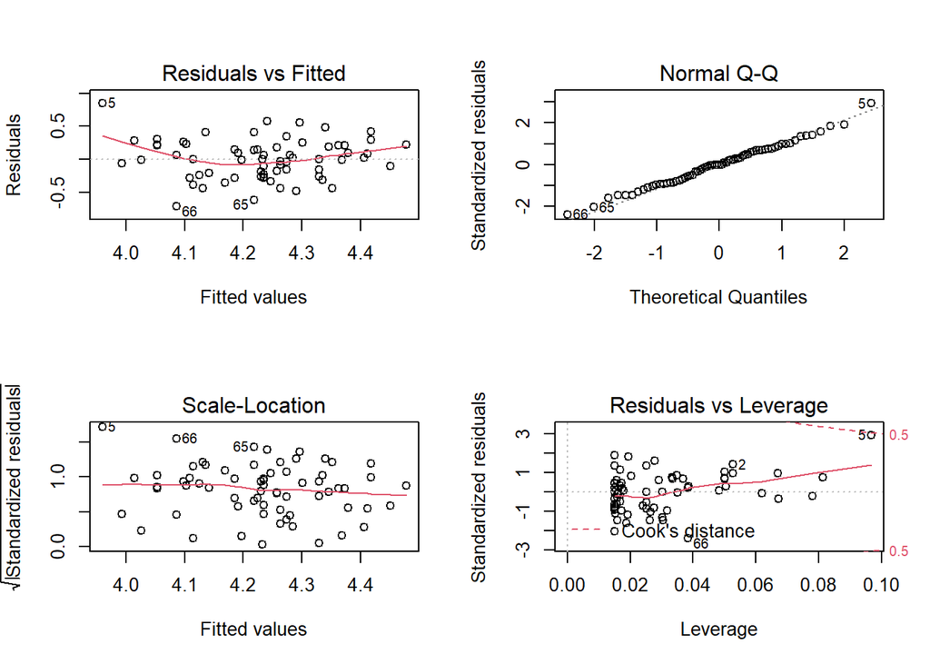

```r
par(mfrow=c(2,2))
plot(model1)
```

```r
dev.off()
```

O resultado é um conjunto de 4 gráficos que permitem avaliar a qualidade do modelo estimado, tendo por base os pressupostos da estimação por OLS:

> Normalidade: Pode ser avaliada através do Q-Q plot. O Q-Q plot permite comparar os quartis da distribuição observada com os quartis de uma distribuição normal. Se os dados observados seguirem uma observação normal, os seus valores irão ser semelhantes aos valores de uma distribuição normal, situando-se sobre a linha diagonal do gráfico.

> Independência das observação: Nenhum dos gráficos permite avaliar este pressuposto, devendo ser inferido pela forma como os dados foram recolhidos e pela sua natureza

> Linearidade: Pode ser avaliada pelo gráfico “Residuals vs Fitted”. Se a VD apresenta uma relação linear com a VI não deverá existir uma relação sistemática entre os valores residuais do modelo e os valores preditos por esse modelo, uma vez que toda a variância sistemática dos dados deve ser capturada pelo modelo, sobrando apenas erro aleatório. A disposição aparentemente aleatória dos valores dos resíduos para os valores estimados é indicativa de que este pressuposto está cumprido

> Homocedasticidade: Pode ser avaliada pelo gráfico “Scale-Location”. Se o pressuposto da homegeneidade das variâncias está cumprido, os pontos no gráfico Scale-location devem estar dispostos de forma aleatória ao longo do eixo horizontal.

O gráfico Residuals vs Leverage acrescenta informação relativamente à existência de observações que podem estar a afetar a qualidade do modelo. Este gráfico permite identificar três tipos de valores:  
* Outliers: valores que não são preditos corretamente pelo modelo e que, por isso apresentam valores muito elevados de erro (neste caso podem ser positivos ou negativos uma vez que são valores estandardizados); * Observações com elevado “leverage” são observações outliers ao nível da VI, isto é valores da VI que são inesperados; * Observações influentes, isto é observações que apresentam um impacto desproporcional na determinação dos parâmetros do modelo. Neste gráfico estas observações são aquelas que estão fora da distância de Cook.

## Modelos de regressão polinomial

O gráfico de dispersão seguinte sugere que a predição o nosso modelo pode ser melhorada se incluirmos um termo quadrático na equação:

```r
df_lm <- coffee[, c("coffee", "rating") ]
df_lm <- df_lm[order(df_lm$coffee),]
df_lm$coffee
```

```
##  [1] 0.0600000 0.1200000 0.1600000 0.1800000 0.2300000 0.2300000 0.2300000
##  [8] 0.2900000 0.2900000 0.3100000 0.3200000 0.3300000 0.3400000 0.3400000
## [15] 0.3600000 0.3700000 0.3800000 0.3900000 0.4400000 0.4700000 0.4700000
## [22] 0.4800000 0.4900000 0.5300000 0.5300000 0.5300000 0.5400000 0.5500000
## [29] 0.5500000 0.5543882 0.5600000 0.5600000 0.5600000 0.5600000 0.5600000
## [36] 0.5700000 0.5800000 0.6000000 0.6000000 0.6100000 0.6100000 0.6100000
## [43] 0.6300000 0.6300000 0.6300000 0.6400000 0.6500000 0.6600000 0.6700000
## [50] 0.6800000 0.7300000 0.7300000 0.7300000 0.7400000 0.7500000 0.7600000
## [57] 0.7700000 0.7900000 0.8000000 0.8100000 0.8200000 0.8700000 0.8800000
## [64] 0.8900000 0.8900000 0.9500000 1.0000000
```

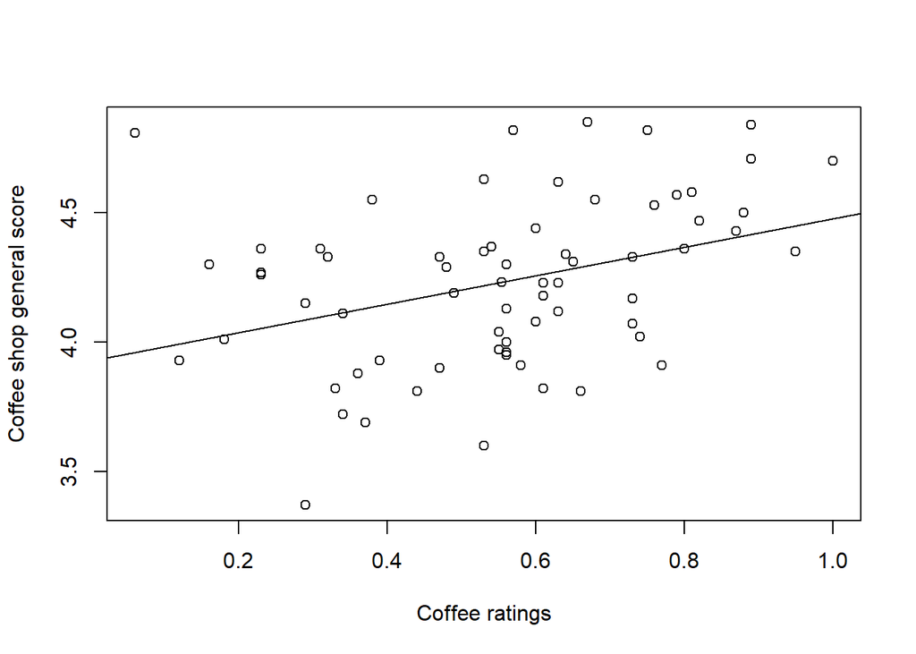

```r
plot(df_lm$rating ~ df_lm$coffee,
     xlab="Coffee ratings",
     ylab="Coffee shop general score")
abline(lm(rating ~ coffee, data = coffee))
```

A equação de um modelo de regressão com um termos quadrático é a seguinte:

$\hat{rating}$ ~ β0 + β1*coffee + β2*$coffee^2$ + ε

No R, este modelo é estimado usando os seguinte código:

```r
model1 <- lm(rating ~ coffee, data=df_lm)
model2 <- lm(rating ~ coffee + I(coffee^2), data=df_lm)
```

O novo termo do modelo **I(coffee^2)** define o termo quadrático na equação. A função **I()** trata o seu conteúdo como um expressão aritmética regular do R e não como conteúdo normal de uma objeto do tipo fórmula. Esta função é necessária uma vez que o símbolo **^** tem um significado específico quando lida numa contexto de fórmula R.

```r
summary(model2)
```

```
##
## Call:
## lm(formula = rating ~ coffee + I(coffee^2), data = df_lm)
##
## Residuals:
##      Min       1Q   Median       3Q      Max
## -0.74327 -0.19514  0.01264  0.17581  0.66311
##
## Coefficients:
##             Estimate Std. Error t value Pr(>|t|)
## (Intercept)   4.3863     0.1836  23.893  < 2e-16 ***
## coffee       -1.5000     0.7101  -2.112  0.03856 *
## I(coffee^2)   1.9253     0.6477   2.972  0.00416 **
## ---
## Signif. codes:  0 '***' 0.001 '**' 0.01 '*' 0.05 '.' 0.1 ' ' 1
##
## Residual standard error: 0.2881 on 64 degrees of freedom
## Multiple R-squared:  0.2363, Adjusted R-squared:  0.2124
## F-statistic: 9.901 on 2 and 64 DF,  p-value: 0.0001794
```

Pelo sumário é possível definir o seguinte modelo de predição:

$\hat{rating}$ = 4.39 - 1.50 * coffee + 1.93 * $coffee^2$ + ε

Ambos os coeficientes de regressão são significativos e a variância explica é de cerca de 23.6%. O termo quadrático significativo (t = 2.972, p = .004) sugere que a sua inclusão melhora o ajustamento do modelo aos dados. O gráfico seguinte aponta no mesmo sentido

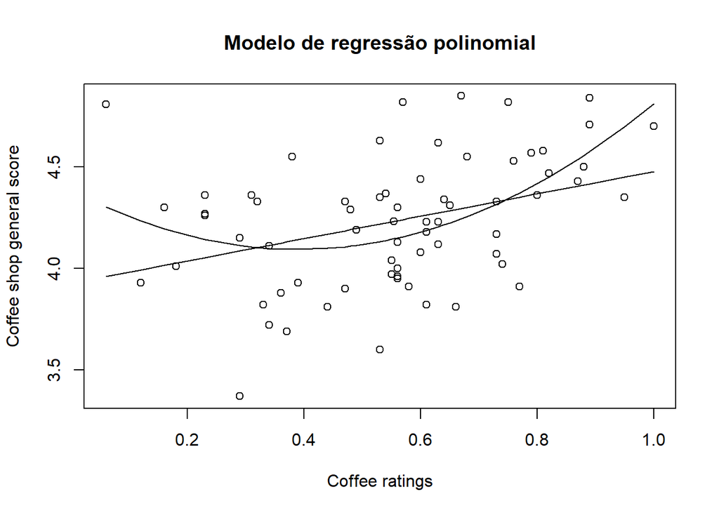

```r
plot(df_lm$coffee, df_lm$rating,
     xlab="Coffee ratings",
     ylab="Coffee shop general score",
     main="Modelo de regressão polinomial")
lines(df_lm$coffee, fitted(model1))
lines(df_lm$coffee, fitted(model2))
```

A função **anova()** permite testar formalmente se existem ou não diferenças entre o ajustamento dos dois modelos, com e sem termos quadrático.

```r
anova(model1, model2)
```

```
## Analysis of Variance Table
##
## Model 1: rating ~ coffee
## Model 2: rating ~ coffee + I(coffee^2)
##   Res.Df    RSS Df Sum of Sq      F  Pr(>F)
## 1     65 6.0454
## 2     64 5.3121  1   0.73333 8.8352 0.00416 **
## ---
## Signif. codes:  0 '***' 0.001 '**' 0.01 '*' 0.05 '.' 0.1 ' ' 1
```

O R disponibiliza vários pacotes que permite apresentar e comparar resultados. O pacote **jtools** é um exemplo desse tipo de pacotes.

```r
library(jtools)
library(huxtable)
summ(model1)
```

| Observations | 67 |
| --- | --- |
| Dependent variable | rating |
| Type | OLS linear regression |

| F(1,65) | 9.79 |
| --- | --- |
| R² | 0.13 |
| Adj. R² | 0.12 |

|  | Est. | S.E. | t val. | p |
| --- | --- | --- | --- | --- |
| (Intercept) | 3.93 | 0.10 | 37.52 | 0.00 |
| coffee | 0.55 | 0.18 | 3.13 | 0.00 |

Standard errors: OLS

```r
summ(model2)
```

| Observations | 67 |
| --- | --- |
| Dependent variable | rating |
| Type | OLS linear regression |

| F(2,64) | 9.90 |
| --- | --- |
| R² | 0.24 |
| Adj. R² | 0.21 |

|  | Est. | S.E. | t val. | p |
| --- | --- | --- | --- | --- |
| (Intercept) | 4.39 | 0.18 | 23.89 | 0.00 |
| coffee | -1.50 | 0.71 | -2.11 | 0.04 |
| I(coffee^2) | 1.93 | 0.65 | 2.97 | 0.00 |

Standard errors: OLS

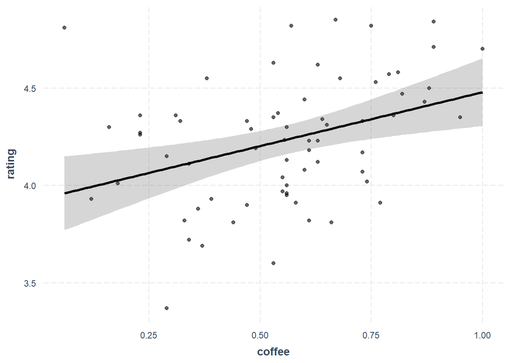

```r
effect_plot(model1, pred = coffee, interval = TRUE, plot.points = TRUE)
```

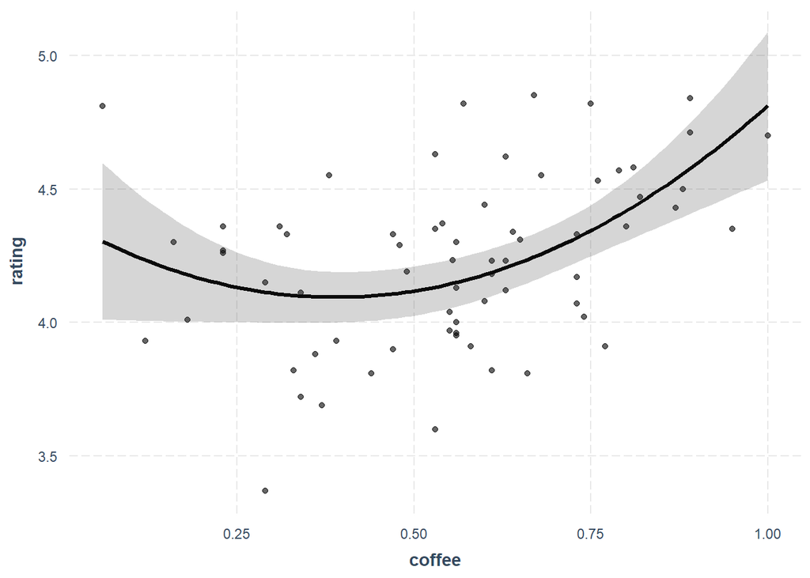

```r
effect_plot(model2, pred = coffee, interval = TRUE, plot.points = TRUE)
```

```r
export_summs(model1, model2)
```

|  | Model 1 | Model 2 |
| --- | --- | --- |
| (Intercept) | 3.93 *** | 4.39 *** |
|  | (0.10) | (0.18) |
| coffee | 0.55 ** | -1.50 * |
|  | (0.18) | (0.71) |
| I(coffee^2) |  | 1.93 ** |
|  |  | (0.65) |
| N | 67 | 67 |
| R2 | 0.13 | 0.24 |
| *** p < 0.001; ** p < 0.01; * p < 0.05. |  |  |

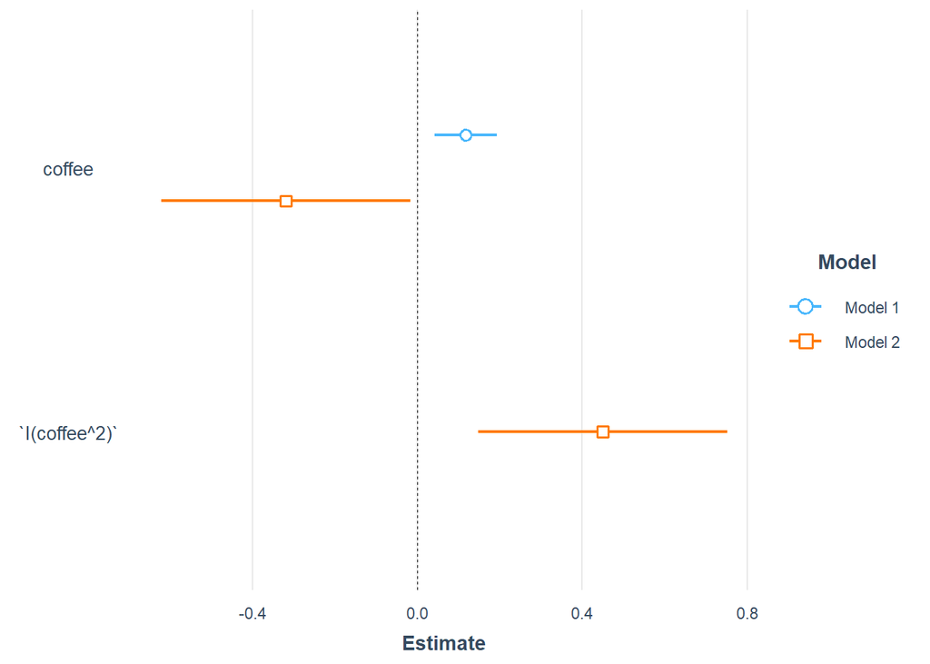

```r
plot_summs(model1, model2, scale = TRUE)
```

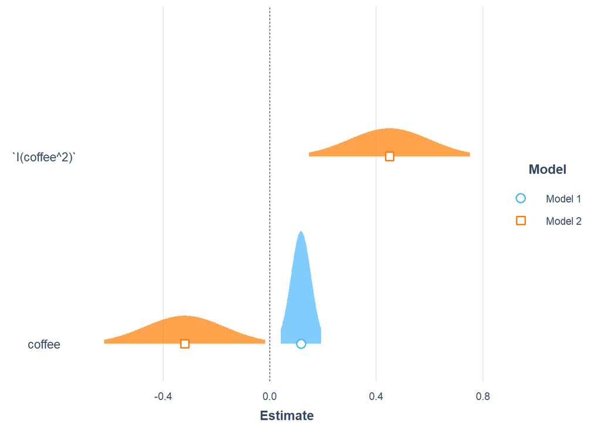

```r
plot_summs(model1, model2, scale = TRUE, plot.distributions = TRUE)
```

## Modelos de regressão multipla (mais do que um preditor)

Quando existe a necessidade incluir mais do que uma variável preditora para explicar uma determinada variável dependente falamos em modelos de regressão múltipla. Imagine-se que pretendemos explicar o score global de um determinado estabelecimento não apenas pela satisfação dos clientes face ao café mas também função de aspetos como a qualidade da comida servida, preço e simpatia do serviço. Tal como os modelos de regressão simples, os modelos de regressão múltipla podem ser testados no R através da função **lm()**.

Um primeiro passo recomendado quando testamos este tipo de modelos é avaliar a associação entre as variáveis que fazem parte do modelo.

```r
vars.model <- c("rating", "coffee", "food", "price", "service")
cor(coffee[, vars.model])
```

```
##             rating      coffee         food       price     service
## rating   1.0000000  0.36174435 -0.142792121  0.10836256 0.293893922
## coffee   0.3617444  1.00000000 -0.416151259  0.08005761 0.081350589
## food    -0.1427921 -0.41615126  1.000000000 -0.02784464 0.003472779
## price    0.1083626  0.08005761 -0.027844644  1.00000000 0.046085991
## service  0.2938939  0.08135059  0.003472779  0.04608599 1.000000000
```

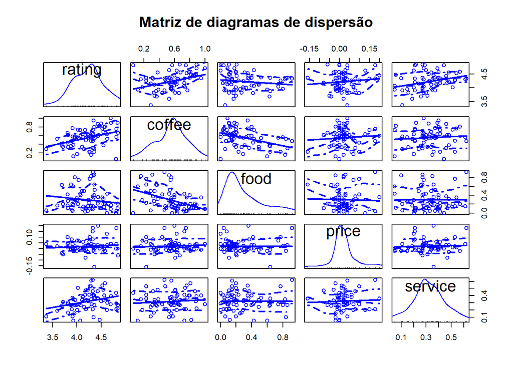

```r
library(car)
scatterplotMatrix(coffee[, vars.model], spread=FALSE, smoother.args=list(lty=2),
                    main="Matriz de diagramas de dispersão")
```

Vamos agora criar um modelo de regressão incluindo os ratings do café, comida, preço e serviço como preditores da satisfação geral dos clientes com o café.

```r
model3 <- lm(rating ~ coffee + food, data = coffee)
summary(model3)
```

```
##
## Call:
## lm(formula = rating ~ coffee + food, data = coffee)
##
## Residuals:
##      Min       1Q   Median       3Q      Max
## -0.71200 -0.24214  0.00022  0.20879  0.85703
##
## Coefficients:
##             Estimate Std. Error t value Pr(>|t|)
## (Intercept)  3.91951    0.14258  27.489  < 2e-16 ***
## coffee       0.55772    0.19548   2.853  0.00582 **
## food         0.01254    0.17148   0.073  0.94194
## ---
## Signif. codes:  0 '***' 0.001 '**' 0.01 '*' 0.05 '.' 0.1 ' ' 1
##
## Residual standard error: 0.3073 on 64 degrees of freedom
## Multiple R-squared:  0.1309, Adjusted R-squared:  0.1038
## F-statistic: 4.821 on 2 and 64 DF,  p-value: 0.01121
```

```r
model4 <- lm(rating ~ coffee + food + price, data = coffee)
summary(model4)
```

```
##
## Call:
## lm(formula = rating ~ coffee + food + price, data = coffee)
##
## Residuals:
##      Min       1Q   Median       3Q      Max
## -0.72232 -0.22599  0.00745  0.19500  0.86213
##
## Coefficients:
##             Estimate Std. Error t value Pr(>|t|)
## (Intercept)  3.91501    0.14334  27.313  < 2e-16 ***
## coffee       0.54763    0.19686   2.782  0.00712 **
## food         0.01183    0.17221   0.069  0.94544
## price        0.44462    0.65358   0.680  0.49882
## ---
## Signif. codes:  0 '***' 0.001 '**' 0.01 '*' 0.05 '.' 0.1 ' ' 1
##
## Residual standard error: 0.3086 on 63 degrees of freedom
## Multiple R-squared:  0.1373, Adjusted R-squared:  0.09619
## F-statistic: 3.341 on 3 and 63 DF,  p-value: 0.0247
```

```r
model5 <- lm(rating ~ coffee + food + price + service, data = coffee)
summary(model5)
```

```
##
## Call:
## lm(formula = rating ~ coffee + food + price + service, data = coffee)
##
## Residuals:
##      Min       1Q   Median       3Q      Max
## -0.59755 -0.18617 -0.01117  0.14978  0.76055
##
## Coefficients:
##              Estimate Std. Error t value Pr(>|t|)
## (Intercept)  3.733437   0.159218  23.449  < 2e-16 ***
## coffee       0.508693   0.191106   2.662  0.00988 **
## food        -0.003997   0.166666  -0.024  0.98094
## price        0.386537   0.632514   0.611  0.54336
## service      0.648836   0.279952   2.318  0.02378 *
## ---
## Signif. codes:  0 '***' 0.001 '**' 0.01 '*' 0.05 '.' 0.1 ' ' 1
##
## Residual standard error: 0.2984 on 62 degrees of freedom
## Multiple R-squared:  0.2061, Adjusted R-squared:  0.1548
## F-statistic: 4.023 on 4 and 62 DF,  p-value: 0.005781
```

Quando existe mais do que um preditor no modelo, o coeficiente de regressão para um determinado preditor indica a medida em que a VD aumenta ou diminui por unidade de mudança desse preditor, mantendo constantes os valores dos outros preditores do modelo.

Por exemplo, do modelo 5, com os 4 preditores, o coeficiente de regressão para a qualidade de serviço é de .64, o que significa que ao aumento de 1 ponto na satisfação com o serviço está associada o aumento de .64 pontos na satisfação global com o estabelecimento, controlando os valores de satisfação com o café, comida e preço. Este coeficiente é significativamente diferente de zero (*p* = .023).

É possível comparar os modelos 1, 3, 4 e 5 com a função **anova()**. Este procedimento é habitualmente designado por regressão linear hierárquica e permite determinar e permite, pela comparação sucessiva de modelos regressão, verificar a mais valia que cada modelo tem, em termos de variância explicada da VD, face aos outros envolvidos na comparação.

```r
export_summs(model1, model3, model4, model5)
```

|  | Model 1 | Model 2 | Model 3 | Model 4 |
| --- | --- | --- | --- | --- |
| (Intercept) | 3.93 *** | 3.92 *** | 3.92 *** | 3.73 *** |
|  | (0.10) | (0.14) | (0.14) | (0.16) |
| coffee | 0.55 ** | 0.56 ** | 0.55 ** | 0.51 ** |
|  | (0.18) | (0.20) | (0.20) | (0.19) |
| food |  | 0.01 | 0.01 | -0.00 |
|  |  | (0.17) | (0.17) | (0.17) |
| price |  |  | 0.44 | 0.39 |
|  |  |  | (0.65) | (0.63) |
| service |  |  |  | 0.65 * |
|  |  |  |  | (0.28) |
| N | 67 | 67 | 67 | 67 |
| R2 | 0.13 | 0.13 | 0.14 | 0.21 |
| *** p < 0.001; ** p < 0.01; * p < 0.05. |  |  |  |  |

```r
anova(model1, model3, model4, model5)
```

| Res.Df | RSS | Df | Sum of Sq | F | Pr(>F) |
| --- | --- | --- | --- | --- | --- |
| 65 | 6.05 |  |  |  |  |
| 64 | 6.04 | 1 | 0.000505 | 0.00567 | 0.94 |
| 63 | 6 | 1 | 0.0441 | 0.495 | 0.484 |
| 62 | 5.52 | 1 | 0.478 | 5.37 | 0.0238 |

Pode ser também interessante comparar a magnitude dos efeitos dos diferentes preditores numa mesma escala. Para o efeito é necessário calcular os coeficiente de regressão estandardizados, usando, por exemplo, a função **lm.beta()**. A função **export_summs()** com o argumento **scale=TRUE** permite também ter acesso aos coeficientes estandardizados.

```r
library(lm.beta)
lm.beta(model2)
```

```
##
## Call:
## lm(formula = rating ~ coffee + I(coffee^2), data = df_lm)
##
## Standardized Coefficients::
## (Intercept)      coffee I(coffee^2)
##   0.0000000  -0.9833797   1.3837589
```

```r
export_summs(model1, model3, model4, model5, scale=TRUE)
```

|  | Model 1 | Model 2 | Model 3 | Model 4 |
| --- | --- | --- | --- | --- |
| (Intercept) | 4.23 *** | 4.23 *** | 4.23 *** | 4.23 *** |
|  | (0.04) | (0.04) | (0.04) | (0.04) |
| coffee | 0.12 ** | 0.12 ** | 0.12 ** | 0.11 ** |
|  | (0.04) | (0.04) | (0.04) | (0.04) |
| food |  | 0.00 | 0.00 | -0.00 |
|  |  | (0.04) | (0.04) | (0.04) |
| price |  |  | 0.03 | 0.02 |
|  |  |  | (0.04) | (0.04) |
| service |  |  |  | 0.09 * |
|  |  |  |  | (0.04) |
| N | 67 | 67 | 67 | 67 |
| R2 | 0.13 | 0.13 | 0.14 | 0.21 |
| All continuous predictors are mean-centered and scaled by 1 standard deviation. *** p < 0.001; ** p < 0.01; * p < 0.05. |  |  |  |  |

## Modelos de regressão multipla com fatores de interação

Uma questão que frequentemente emerge no processo de estimação de modelos de regressão tem a ver com a interacção entre variáveis independentes. Vamos assumir que estamos interessados em clarificar os efeitos da satisfação com o café e qualidade do serviço sobre o score geral de satisfação atribuido a cada um dos estabelecimentos. Podemos ajustar um modelo de regressão incluindo estes dois preditores e um terceiro preditor que capta a sua interacção. No R o termo de interacção é criado com o operador **:** tal como demonstrado no código seguinte.

```r
model6 <- lm(rating ~ coffee + service, data = coffee)
summary(model6)
```

```
##
## Call:
## lm(formula = rating ~ coffee + service, data = coffee)
##
## Residuals:
##      Min       1Q   Median       3Q      Max
## -0.58606 -0.19621 -0.02273  0.16190  0.75698
##
## Coefficients:
##             Estimate Std. Error t value Pr(>|t|)
## (Intercept)   3.7335     0.1297  28.786  < 2e-16 ***
## coffee        0.5187     0.1710   3.034  0.00348 **
## service       0.6554     0.2759   2.375  0.02055 *
## ---
## Signif. codes:  0 '***' 0.001 '**' 0.01 '*' 0.05 '.' 0.1 ' ' 1
##
## Residual standard error: 0.2946 on 64 degrees of freedom
## Multiple R-squared:  0.2013, Adjusted R-squared:  0.1763
## F-statistic: 8.063 on 2 and 64 DF,  p-value: 0.0007531
```

```r
model7 <- lm(rating ~ coffee + service + coffee:service, data = coffee)
summary(model7)
```

```
##
## Call:
## lm(formula = rating ~ coffee + service + coffee:service, data = coffee)
##
## Residuals:
##      Min       1Q   Median       3Q      Max
## -0.53443 -0.19084 -0.00699  0.20422  0.59075
##
## Coefficients:
##                Estimate Std. Error t value Pr(>|t|)
## (Intercept)      3.1807     0.2436  13.057  < 2e-16 ***
## coffee           1.5494     0.4237   3.657 0.000522 ***
## service          2.3854     0.7071   3.373 0.001274 **
## coffee:service  -3.1841     1.2074  -2.637 0.010519 *
## ---
## Signif. codes:  0 '***' 0.001 '**' 0.01 '*' 0.05 '.' 0.1 ' ' 1
##
## Residual standard error: 0.2818 on 63 degrees of freedom
## Multiple R-squared:  0.2807, Adjusted R-squared:  0.2464
## F-statistic: 8.194 on 3 and 63 DF,  p-value: 0.0001097
```

```r
anova(model6, model7)
```

| Res.Df | RSS | Df | Sum of Sq | F | Pr(>F) |
| --- | --- | --- | --- | --- | --- |
| 64 | 5.56 |  |  |  |  |
| 63 | 5 | 1 | 0.552 | 6.95 | 0.0105 |

No sumário do modelo 7 verificamos que o coeficiente de regressão que representa a interação entre satisfação com o café e com serviço é significativo. Isto significa que o efeito de um dos preditores (eg. “coffee”) sobre a VD dependen do nível do outro preditor (eg.: “service”). Assim, a relação entre satisfação com café e satisfação geral varia de acordo com a satisfação do serviço.

```r
mean(coffee$service)-sd(coffee$service)
```

```
## [1] 0.19055
```

```r
mean(coffee$service)
```

```
## [1] 0.3224252
```

```r
mean(coffee$service)+sd(coffee$service)
```

```
## [1] 0.4543005
```

Assim com o aumento da satisfação com o serviço (0.19, 0.32 e 0.45) a mudança esperada no rating geral por unidade de satisfação com o café parece diminuir (.95, .53 e .12). Por outras palavras o efeito da qualidade do café na satisfação geral dos clientes parece atenuar-se quando os níveis de satisfação com o serviço aumentam. Os gráficos seguintes permitem visualizar esta interação.

```r
library(effects)
```

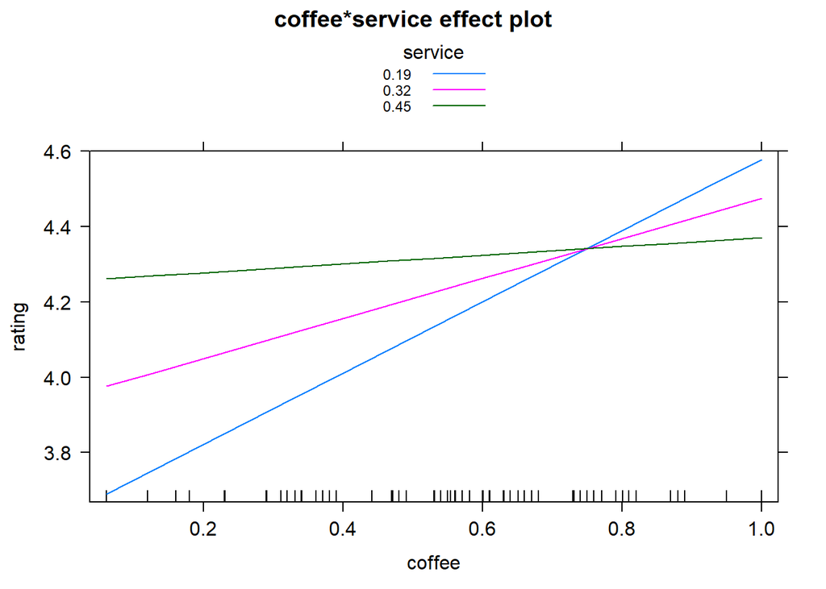

```r
plot(effect(term="coffee:service", mod=model7, xlevels=list(service=c(0.19, 0.32, 0.45))), multiline=TRUE)
```

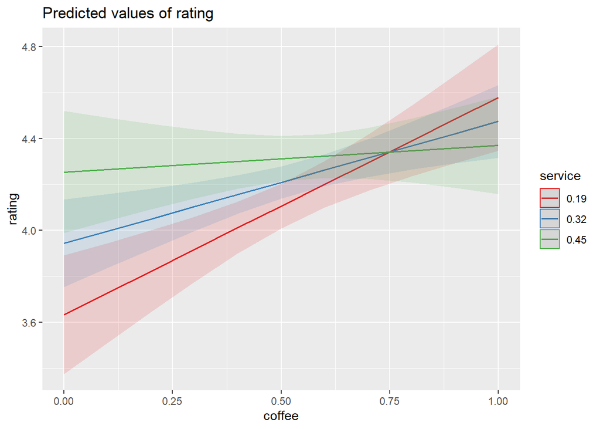

```r
library(sjPlot)
library(sjmisc)
library(ggplot2)
plot_model(model7, type = "pred", terms = c("coffee", "service"))
```

# 6. Análise de variância

Nos modelos de regressão anteriores utilizamos VIs contínuas para predizer uma VD também contínua. É possível expandir o este modelo para incluir fatores ordinais como VI e mesmo combinar variáveis contínuas e fatores como VI’s no mesmo modelo. Por norma, quando são incluídos fatores no modelo o foco deixa de ser a predição da VD, para passar a ser também a análise de diferenças entre grupos.

O desenvolvimento da análise de variância está muito associada a desenhos de investigação experimental. Existe toda uma nomenclatura própria associada a este tipo de análise, que pode por vezes ser confusa. Para clarificar alguma da terminologia associada à análise de variância recorremos ao exemplo clássico de um estudo experimental com grupo de controlo (GC) e grupo experimental (GE), em que se pretende avaliar o impacto de uma intervenção sobre o níveis de ansiedade dos participantes (Ans.).

Neste exemplo, o fator “between-groups” é o grupo a que participante é alocado, GC ou GE (dois níveis do fator). Cada participante apenas pode pertencer a um grupo. Assim, neste modelo a VD são os resultados de ansiedade dos participantes e a VI é o fator de dois níveis correspondente ao grupo a que o sujeito foi alocado (GC ou GE). Falamos em “balanced designs” quando existe o mesmo número de observações nos diferentes níveis do fator e em “unbalanced designs” quando esta condição não se verifica.

Porque neste modelo apenas estamos interessados no efeito de um fator sobre a VD, o design é denominado de “one-way between groups ANOVA”. Os efeitos neste contexto de modelação são avaliados com recurso ao F-test, já apresentado anteriormente.

Se o interesse for perceber o efeito da intervenção sobre a ansiedade ao longo do tempo, a denominação mais comum é “one-way within groups ANOVA”. Neste caso, o tempo é um fator “within-group”, uma vez que cada sujeito é avaliado mais do que uma vez. Este design também se pode chamar de “repeated measures ANOVA”. Neste contexto, é fácil ampliar o modelo para perceber em que medida existe uma interação entre os dois fatores, grupo e tempo, afeta a VD . Para o efeito, simplesmente acrescentamos aos dois efeitos principais (do grupo e do tempo) o termo de interação. Este design é habitualmente denominado de “factorial ANOVA”. A utilização de 2 fatores no modelo produz uma “two-way ANOVA”, enquanto que a utilização de 3 fatores dá origem a um modelo designado por “three-way ANOVA”. No caso do design incluir simultaneamente fatores “between groups” e “within-groups”, como é o caso dos fatores grupo (GC vs GE) e tempo, o design pode ser também chamado de “mixed-model ANOVA”. Assim, o termo “two-way mixed-model factorial ANOVA” representará um modelo que inclui como preditores dois fatores, um “between groups” e outro “within-groups”, bem como a sua interação.

Este modelo de ANOVA pode ser também expandido para incluir variáveis contínuas como preditores. No contexto da investigação experimental as variáveis contínuas são essencialmente vistas como variáveis ruído e que importa controlar no modelo para que o efeito dos fatores seja estimado de forma mais realista. Na análise de variância este tipo de variáveis são denominadas de covariáveis. Um modelo de análise de variância que, para além dos fatores, inclui uma ou mais covariaveis é apelidado de análise de convariância ou ANCOVA. Finalmente, podemos ainda ampliar o modelo para incluir mais do que uma variável dependente. Quando este é o caso, falamos de MANOVA.

Apesar da flexibilidade dos modelos de análise de variância, no contexto deste curso iremos restringir-nos à apresentação e discussão da one-way ANOVA.

## Estimação de modelos de análise de variância no R

Apesar dos modelos de regressão já apresentados e os modelos de análise de variância surgirem tradicionalmente em campos de investigação diferentes (estudos correlacionais ou estudos experimentais), ambos são casos especiais da aplicação do GLM (“General Linear Model”). Por conseguinte, no R é possível analisar uma ANOVA (ou outro modelo de análise de variância) através da função lm(), usada anteriormente para estimar modelos de regressão. Isto será demonstrado mais à frente neste curso. Apesar disso, é mais comum utilizar a função aov() quando pretendemos estimar modelos de análise de variância no R. Apesar das funções lm() e aov() serem equivalentes, a função aov() apresenta os resultados num formato mais habitual e familiar à investigação de cariz experimental.

Os seguintes símbolos podem ser utilizados na especificação da fórmula do modelo:

| símbolo | significado |
| --- | --- |
| : | Define interação entre fatores |
| * | Atalho para definir interações entre todos os fatores do modelo (y ~ A * B * C <==> y ~ A + B + C + A:B + A:C + B:C + A:B:C) |
| ^ | Define interação a um nível específico ((y ~ A * B * C)^2 <==> y ~ A + B + C + A:B + A:C + B:C) |
| . | Define todas as variáveis da DF como fatores no modelo ( y ~ . <==> y ~ A + B + C) |

Na tabela seguinte apresentam-se as fórmulas para alguns dos designs de análise de variância mais comuns.

| Design | Fórmula |
| --- | --- |
| One-way ANOVA | y ~ A |
| One-way ANCOVA com 1 covariável (x) | y ~ x + A |
| Two-way factorial ANOVA | y ~ A * B |
| Two-way factorial ANOVA com 2 covariáveis (x1 e x2) | y ~ x1 + x2 + A * B |
| One-way within-groups ANOVA | y ~ A + Error(Subject/A) |
| Repeate measures ANOVA com 1 between-groups factor (B) e 1 fator within-groups (w) | y ~ B * W + Error(Subject/W) |

A ordem pela qual os efeitos são especificados na fórmula não é irrelevante quando (a) existe mais do que um fator e o design é “unbalanced” ou (b) são incluídas covariáveis. Nestas circunstâncias as VI’s do modelo estão correlacionadas, não existindo por isso uma forma não ambígua de perceber o contributo independente de cada uma dessas VI’s sobre a VD. A seguinte fórmula define um modelo de ANOVA fatorial com y a ser estimado pelos fatores A e B, e sua interação, A:B:

> y ~ A + B + A:B

Assumindo que o modelo anterior vai ser aplicado sobre um “unbalanced design”, existem 3 abordagem gerais para perceber a quantidade de variância de y que é explicada pelos diferentes efeitos preditores do modelo (i.e., dois efeitos principais (A e B) e um efeito de interação (A:B)):

> Abordagem sequencial (tipo I) – Os efeitos são ajustados aos efeitos que surgem primeiro na fórmula. No exemplo anterior:
> > 1. é calculado efeito de A;
> > 2. o efeito de B é ajustado ao efeito de A;
> > 3. o efeito de A:B é ajustado aos efeitos de A e B.

> Abordagem hierárquica (tipo II) – Cada efeito é ajustado a todos os efeitos do mesmo nível ou de nível inferior. No exemplo anterior:
> > 1. o efeito de A é ajustado ao efeito de B;
> > 2. o efeito de B é ajustado ao efeito de A;
> > 3. o efeito de A:B é ajustado aos efeitos de A e B.

> Abordagem marginal (tipo III) – Cada efeito é ajustado a todos os outros efeitos estimados no modelo. No exemplo anterior:
> > 1. o efeito de A é ajustado ao efeito de B e A:B;
> > 2. o efeito de B é ajustado ao efeito de A e A:B;
> > 3. o efeito de A:B é ajustado aos efeitos de A e B.

Por defeito, o R aplica a abordagem sequencial (tipo I). Outros pacotes estatísticos como o SAS ou o SPSS aplicam por defeito a abordagem marginal (tipo III). Por conseguinte, ao utilizar a função oav() com modelo ortogonais (modelos em que as VD estão correlacionas), faz sentido especificar primeiro na fórmula do modelo os efeitos mais fundamentais, por exemplo as covariáveis. Se for importante aplicar uma abordagem diferente da abordagem sequencial (tipo I), o utilizador poderá recorrer à função Anova() do pacote car. Esta função permite aplicar as abordagens hierárquica (tipo II) e marginal (tipo III) na estimação do modelo de variância.

## One-way ANOVA

Como já foi dito, aplica-se a one-way ANOVA quando estamos interessados em comparar a média de uma variável dependente em dois ou grupos definidos por um fator. O exemplo seguinte estima este modelo utilizando a função aov().

```r
names(coffee)
```

```
##  [1] "coffee_shop_name" "cityarea"         "num_reviews"      "popular"
##  [5] "rating"           "ratingMorning"    "ratingLunch"      "ratingAfternoon"
##  [9] "ratingDinner"     "coffee"           "coffee_rec"       "tea"
## [13] "tea_rec"          "food"             "food_rec"         "alcohol"
## [17] "alcohol_rec"      "vibe"             "vibe_rec"         "service"
## [21] "service_rec"      "price"            "price_rec"        "convenience"
## [25] "convenience_rec"  "internet"         "seating"
```

```r
replications(rating~cityarea*convenience_rec, data=coffee)
```

```
## $cityarea
## cityarea
## downtown eastcity westcity
##       24       28       15
##
## $convenience_rec
## convenience_rec
##  Very Bad       Bad        Ok      Good Very Good
##         3        12        34        14         4
##
## $`cityarea:convenience_rec`
##           convenience_rec
## cityarea   Very Bad Bad Ok Good Very Good
##   downtown        0   3 11    7         3
##   eastcity        1   7 17    2         1
##   westcity        2   2  6    5         0
```

```r
# replications(rating~cityarea*convenience_rec, data=coffee) # check if the design is balance or unbalanced
table(coffee$cityarea)
```

```
##
## downtown eastcity westcity
##       24       28       15
```

```r
aggregate(coffee$rating, by=list(coffee$cityarea), FUN=mean)
```

| Group.1 | x |
| --- | --- |
| downtown | 4.54 |
| eastcity | 4.14 |
| westcity | 3.92 |

```r
aggregate(coffee$rating, by=list(coffee$cityarea), FUN=sd)
```

| Group.1 | x |
| --- | --- |
| downtown | 0.195 |
| eastcity | 0.21 |
| westcity | 0.254 |

```r
# ?aov
model1 <- aov(rating ~ cityarea, data = coffee)
summary(model1)
```

```
##             Df Sum Sq Mean Sq F value   Pr(>F)
## cityarea     2  3.984  1.9919    42.9 1.52e-12 ***
## Residuals   64  2.972  0.0464
## ---
## Signif. codes:  0 '***' 0.001 '**' 0.01 '*' 0.05 '.' 0.1 ' ' 1
```

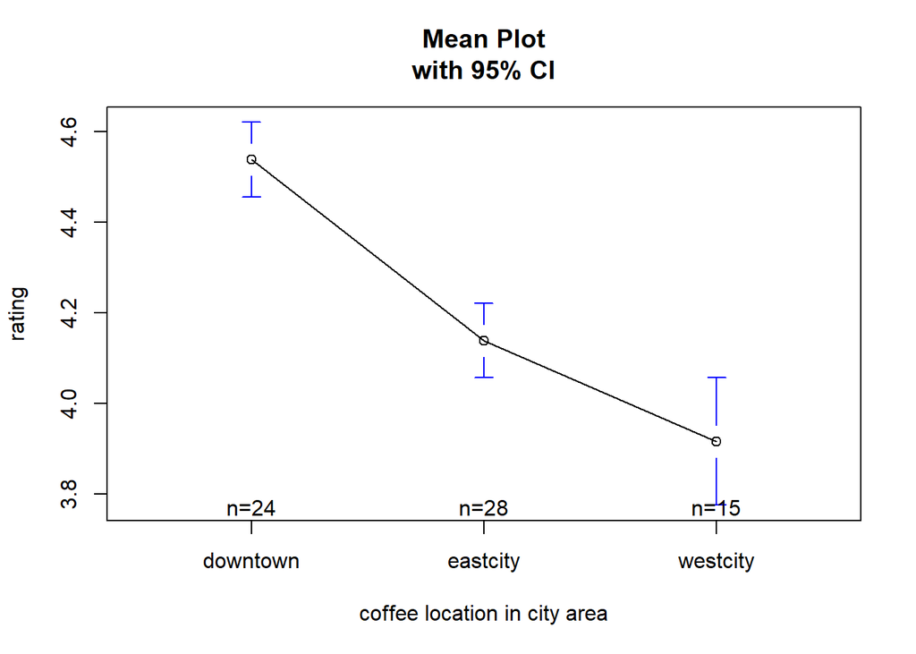

```r
if (!require("gplots")) install.packages("gplots")
library(gplots)
plotmeans(coffee$rating ~ coffee$cityarea, xlab="coffee location in city area", ylab="rating",
          main="Mean Plot\nwith 95% CI")
```

### Múltiplas comparações

O resultado do F-test (p < .05) evidencia que o rating médio dos cafés varia em função da sua localização. Importa agora perceber que cafés diferem entre sim. Esta questão pode ser respondida através de comparações múltiplas entre cafés.

```r
# Tukey HSD pairwise group comparisons
TukeyHSD(model1)
```

```
##   Tukey multiple comparisons of means
##     95% family-wise confidence level
##
## Fit: aov(formula = rating ~ cityarea, data = coffee)
##
## $cityarea
##                         diff        lwr         upr     p adj
## eastcity-downtown -0.3989533 -0.5427799 -0.25512674 0.0000000
## westcity-downtown -0.6216667 -0.7918446 -0.45148874 0.0000000
## westcity-eastcity -0.2227133 -0.3881500 -0.05727667 0.0054775
```

```r
# ?TukeyHSD
```

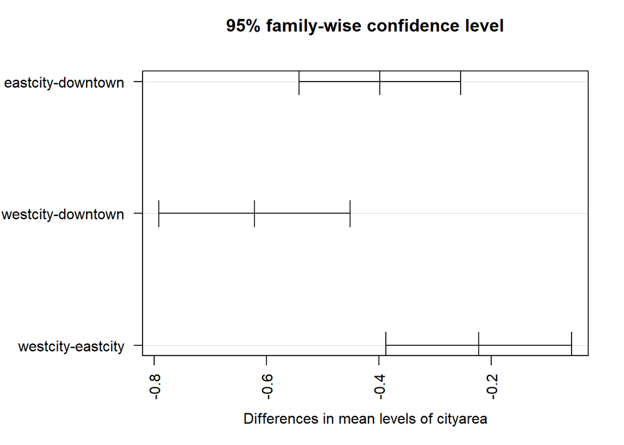

```r
# ploting the confidence intervals for the multiple comparisons
par(las=2) # rotates axis labels
par(mar=c(5,8,4,2)) # increases the left margin are
plot(TukeyHSD(model1))
```

```r
dev.off()
```

```r
# Multiple comparisons using the multcomp package
if (!require("multcomp")) install.packages("multcomp")
library(multcomp)
par(mar=c(5,4,6,2)) # increases top margin
# ?glht
tuk <- glht(model1, linfct=mcp(cityarea = "Tukey")) # reproduces Tukey HSD test
tuk
```

```
##
##   General Linear Hypotheses
##
## Multiple Comparisons of Means: Tukey Contrasts
##
##
## Linear Hypotheses:
##                          Estimate
## eastcity - downtown == 0  -0.3990
## westcity - downtown == 0  -0.6217
## westcity - eastcity == 0  -0.2227
```

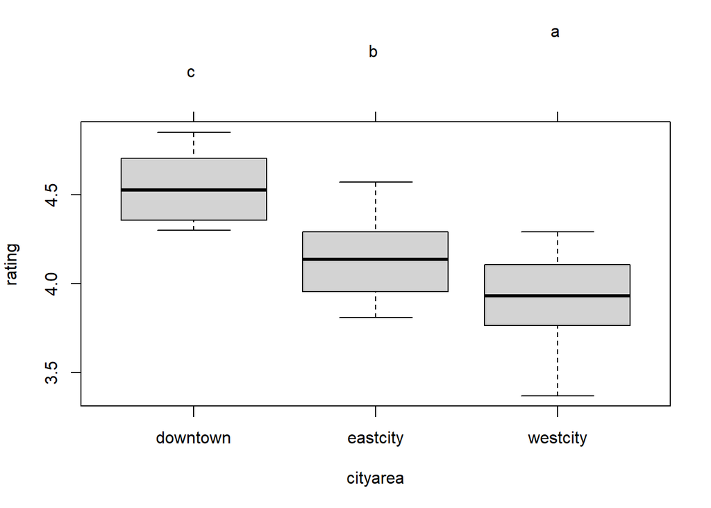

```r
plot(cld(tuk, level=.05),col="lightgrey")
```

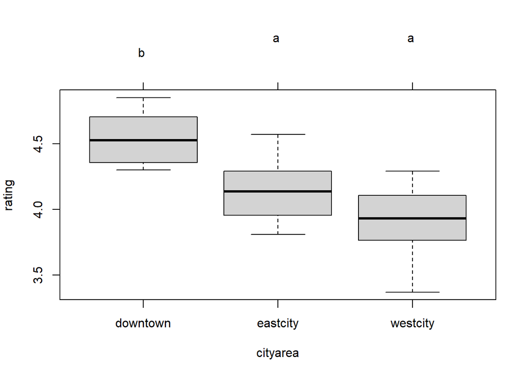

```r
plot(cld(tuk, level=.001),col="lightgrey")
```

```r
# Other multiple comparisons tests
if (!require("DescTools")) install.packages("DescTools")
library(DescTools)

# ?PostHocTest
PostHocTest(model1, method = "lsd") # options for method are: "hsd" (Tukey), "bonferroni", "lsd", "scheffe", "newmankeuls", "duncan"
```

```
##
##   Posthoc multiple comparisons of means : Fisher LSD
##     95% family-wise confidence level
##
## $cityarea
##                         diff     lwr.ci      upr.ci    pval
## eastcity-downtown -0.3989533 -0.5187015 -0.27920513 7.5e-09 ***
## westcity-downtown -0.6216667 -0.7633547 -0.47997867 1.5e-12 ***
## westcity-eastcity -0.2227133 -0.3604538 -0.08497285  0.0020 **
##
## ---
## Signif. codes:  0 '***' 0.001 '**' 0.01 '*' 0.05 '.' 0.1 ' ' 1
```

```r
PostHocTest(model1, method = "hsd")
```

```
##
##   Posthoc multiple comparisons of means : Tukey HSD
##     95% family-wise confidence level
##
## $cityarea
##                         diff     lwr.ci      upr.ci    pval
## eastcity-downtown -0.3989533 -0.5427799 -0.25512674 2.2e-08 ***
## westcity-downtown -0.6216667 -0.7918446 -0.45148874 1.4e-11 ***
## westcity-eastcity -0.2227133 -0.3881500 -0.05727667  0.0055 **
##
## ---
## Signif. codes:  0 '***' 0.001 '**' 0.01 '*' 0.05 '.' 0.1 ' ' 1
```

```r
PostHocTest(model1, method = "scheffe")
```

```
##
##   Posthoc multiple comparisons of means: Scheffe Test
##     95% family-wise confidence level
##
## $cityarea
##                         diff     lwr.ci      upr.ci    pval
## eastcity-downtown -0.3989533 -0.5491784 -0.24872827 4.9e-08 ***
## westcity-downtown -0.6216667 -0.7994154 -0.44391798 1.1e-11 ***
## westcity-eastcity -0.2227133 -0.3955098 -0.04991683  0.0080 **
##
## ---
## Signif. codes:  0 '***' 0.001 '**' 0.01 '*' 0.05 '.' 0.1 ' ' 1
```

```r
# compare p-values:
round(cbind(
  lsd = PostHocTest(model1, method="lsd")$cityarea[,"pval"],
  hsd = PostHocTest(model1, method="hsd")$cityarea[,"pval"],
  scheffe = PostHocTest(model1, method="scheffe")$cityarea[,"pval"]), 4)
```

```
##                     lsd    hsd scheffe
## eastcity-downtown 0.000 0.0000   0.000
## westcity-downtown 0.000 0.0000   0.000
## westcity-eastcity 0.002 0.0055   0.008
```

### Diagnóstico da modelo

A análise dos pressupostos subjacentes à estimação do modelo pode ser feita da mesma forma que análise dos pressupostos do modelo de regressão.

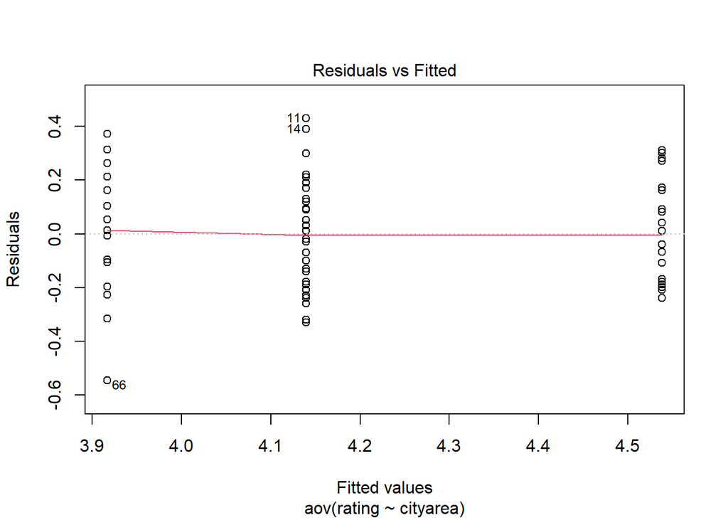

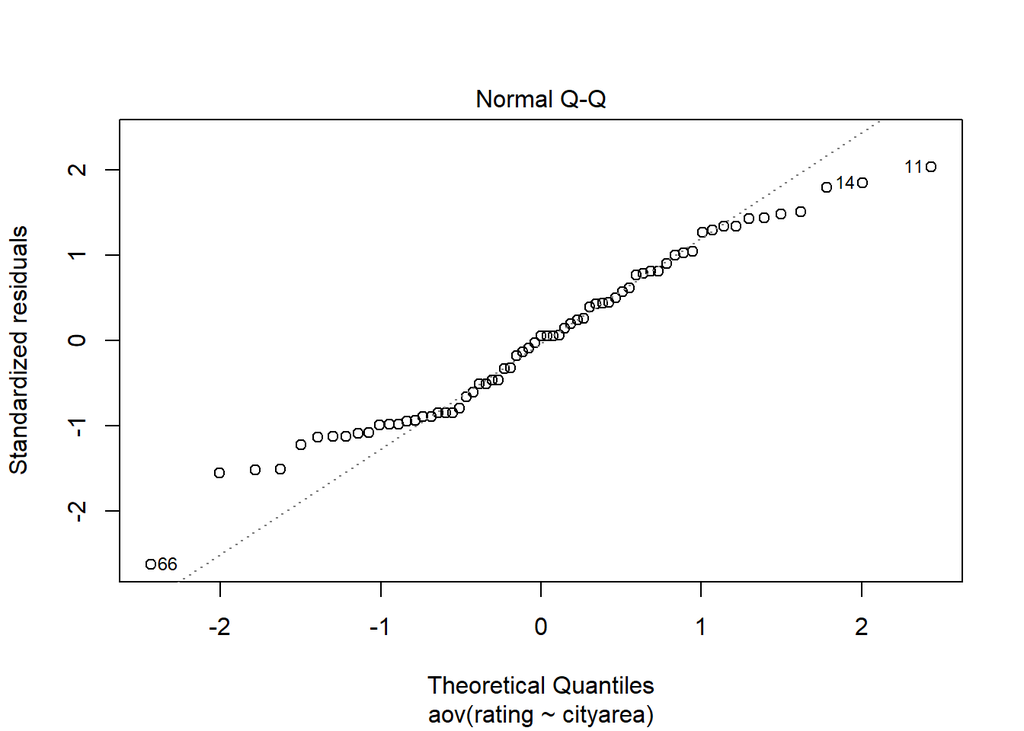

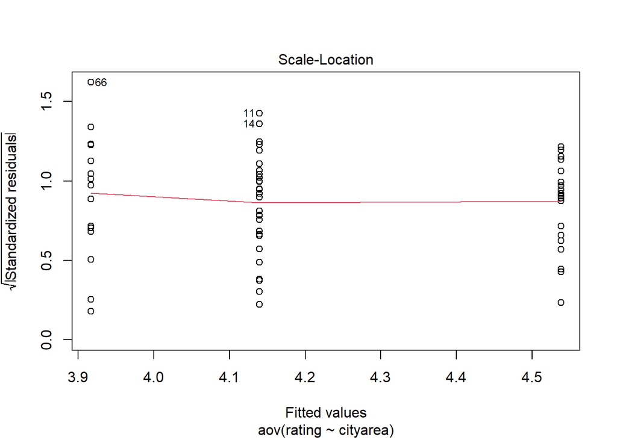

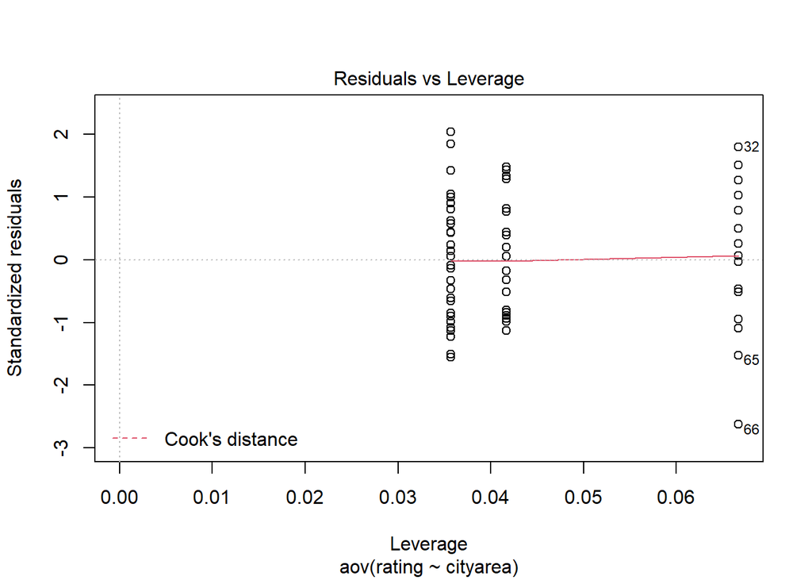

```r
plot(model1)
```

Tal como foi discutido anteriormente para os modelo de regressão, também os modelos de análise de variância pressupõem a normalidade da VI e a homogeneidade da variância para os diferentes níveis da VD. Em alternativa à função plot() a normalidade da VD pode ser avaliada através da função qqPlot() do pacote car.

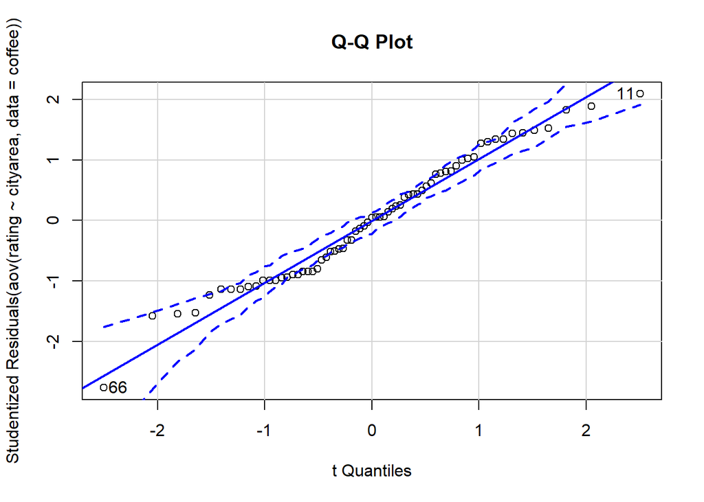

```
## [1] 11 66
```

```r
library(car)
qqPlot(aov(rating ~ cityarea, data=coffee),
       simulate=TRUE, main="Q-Q Plot", labels=FALSE)
```

A homogeneidade das variâncias pode ser testada por exemplo através do Bartlett’s test.

```r
bartlett.test(rating ~ cityarea, data=coffee)
```

```
##
##  Bartlett test of homogeneity of variances
##
## data:  rating by cityarea
## Bartlett's K-squared = 1.2633, df = 2, p-value = 0.5317
```

A homogeneidade das variâncias pode ser testada por exemplo através do Bartlett’s test. Ou, em alternativa os teste de Fligner-Killeen, através da função fligner.test() , de Brown-Forsythe, através da função hov().

```r
fligner.test(rating ~ cityarea, data=coffee)
```

```
##
##  Fligner-Killeen test of homogeneity of variances
##
## data:  rating by cityarea
## Fligner-Killeen:med chi-squared = 0.99164, df = 2, p-value = 0.6091
```

```r
if (!require("HH")) install.packages("HH")
library(HH)
hov(rating ~ cityarea, data=coffee)
```

```
##
##  hov: Brown-Forsyth
##
## data:  rating
## F = 0.33688, df:cityarea = 2, df:Residuals = 64, p-value = 0.7153
## alternative hypothesis: variances are not identical
```

Finalmente, a presença de outliers pode ser detetada pela função outlierTest() do pacote car.

```r
library(car)
outlierTest(model1) # no indication of outliers (NA occurs when p>1)
```

```
## No Studentized residuals with Bonferroni p < 0.05
## Largest |rstudent|:
##     rstudent unadjusted p-value Bonferroni p
## 66 -2.758194          0.0075974      0.50903
```

```r
#?outlierTest
```

## ANOVA e regressão

Como referido anteriormente a análise de variância e a regressão são derivações do GLM. Por conseguinte, é possível estimar modelos de variância, como o modelo one-way ANOVA antes apresentado, utilizando a função lm(). Primeiro, estimamos o modelo utilizando a função aov().

```r
levels(coffee$cityarea)
```

```
## [1] "downtown" "eastcity" "westcity"
```

```r
modelfit_oav <- aov(rating ~ cityarea, data = coffee)
summary(modelfit_oav)
```

```
##             Df Sum Sq Mean Sq F value   Pr(>F)
## cityarea     2  3.984  1.9919    42.9 1.52e-12 ***
## Residuals   64  2.972  0.0464
## ---
## Signif. codes:  0 '***' 0.001 '**' 0.01 '*' 0.05 '.' 0.1 ' ' 1
```

De seguida, o mesmo modelo é estimado com recurso à função lm().

```r
modelfit_lm <- lm(rating ~ cityarea, data = coffee)
summary(modelfit_lm)
```

```
##
## Call:
## lm(formula = rating ~ cityarea, data = coffee)
##
## Residuals:
##      Min       1Q   Median       3Q      Max
## -0.54667 -0.18386  0.01062  0.16698  0.43062
##
## Coefficients:
##                  Estimate Std. Error t value Pr(>|t|)
## (Intercept)       4.53833    0.04399 103.178  < 2e-16 ***
## cityareaeastcity -0.39895    0.05994  -6.656 7.45e-09 ***
## cityareawestcity -0.62167    0.07092  -8.765 1.46e-12 ***
## ---
## Signif. codes:  0 '***' 0.001 '**' 0.01 '*' 0.05 '.' 0.1 ' ' 1
##
## Residual standard error: 0.2155 on 64 degrees of freedom
## Multiple R-squared:  0.5728, Adjusted R-squared:  0.5594
## F-statistic:  42.9 on 2 and 64 DF,  p-value: 1.519e-12
```

Para perceber o resultado da aplicação da função lm() ao modelo anterior, é útil perceber como internamente o R lida com variáveis categoriais no processo de estimação de modelos de regressão. Uma vez que os GLM apenas acomodam preditores numérico, quando a função **lm()** “encontra” um fator na sua fórmula, substitui esse fator por um conjunto de variáveis numéricas que representam os contrastes entre os diferentes níveis do fator. Assim, se o fator tem k níveis, o número de variáveis de contraste geradas será k-1. O R disponibiliza 5 métodos diferentes para criar estas variáveis contraste.

```r
contr.helmert(c("L1", "L2", "L3", "L4", "L5")) # "contrast the second level with the first, the third with the average of the first two, and so on"
```

```
##    [,1] [,2] [,3] [,4]
## L1   -1   -1   -1   -1
## L2    1   -1   -1   -1
## L3    0    2   -1   -1
## L4    0    0    3   -1
## L5    0    0    0    4
```

```r
contr.poly(c("L1", "L2", "L3", "L4", "L5")) # constrast used for trend analysis, using linear, quadratic, cubic... for each constrast variable
```

```
##              .L         .Q            .C         ^4
## [1,] -0.6324555  0.5345225 -3.162278e-01  0.1195229
## [2,] -0.3162278 -0.2672612  6.324555e-01 -0.4780914
## [3,]  0.0000000 -0.5345225 -4.095972e-16  0.7171372
## [4,]  0.3162278 -0.2672612 -6.324555e-01 -0.4780914
## [5,]  0.6324555  0.5345225  3.162278e-01  0.1195229
```

```r
contr.sum(c("L1", "L2", "L3", "L4", "L5")) # contrasts are constrained to sum to zero
```

```
##    [,1] [,2] [,3] [,4]
## L1    1    0    0    0
## L2    0    1    0    0
## L3    0    0    1    0
## L4    0    0    0    1
## L5   -1   -1   -1   -1
```

```r
contr.treatment(c("L1", "L2", "L3", "L4", "L5")) #  contrasts each level with the baseline level (specified by base) - dummy coding
```

```
##    L2 L3 L4 L5
## L1  0  0  0  0
## L2  1  0  0  0
## L3  0  1  0  0
## L4  0  0  1  0
## L5  0  0  0  1
```

```r
contr.SAS(c("L1", "L2", "L3", "L4", "L5")) # Similar to contr.treatment, but sets the base level to be the last level of the factor
```

```
##    L1 L2 L3 L4
## L1  1  0  0  0
## L2  0  1  0  0
## L3  0  0  1  0
## L4  0  0  0  1
## L5  0  0  0  0
```

Por defeito o R emprega o “treatment contrast” em fatores não ordenados e “orthogonal polynomials” em fatores ordenados. O modelo anterior emprega as seguintes variáveis contraste.

```r
coffee$cityarea
```

```
##  [1] downtown downtown downtown downtown downtown downtown downtown downtown
##  [9] downtown downtown eastcity downtown downtown eastcity downtown downtown
## [17] eastcity downtown downtown eastcity downtown downtown eastcity downtown
## [25] downtown eastcity downtown downtown eastcity downtown downtown westcity
## [33] eastcity eastcity westcity eastcity eastcity westcity eastcity eastcity
## [41] westcity eastcity eastcity westcity eastcity eastcity westcity eastcity
## [49] eastcity westcity eastcity eastcity westcity eastcity eastcity westcity
## [57] eastcity eastcity westcity eastcity eastcity westcity westcity westcity
## [65] westcity westcity eastcity
## Levels: downtown eastcity westcity
```

```r
levels(coffee$cityarea)
```

```
## [1] "downtown" "eastcity" "westcity"
```

```r
contrasts(coffee$cityarea) # same as contr.treatment()
```

```
##          eastcity westcity
## downtown        0        0
## eastcity        1        0
## westcity        0        1
```

```r
modelfit <- lm(rating ~ cityarea, data = coffee)
summary(modelfit)
```

```
##
## Call:
## lm(formula = rating ~ cityarea, data = coffee)
##
## Residuals:
##      Min       1Q   Median       3Q      Max
## -0.54667 -0.18386  0.01062  0.16698  0.43062
##
## Coefficients:
##                  Estimate Std. Error t value Pr(>|t|)
## (Intercept)       4.53833    0.04399 103.178  < 2e-16 ***
## cityareaeastcity -0.39895    0.05994  -6.656 7.45e-09 ***
## cityareawestcity -0.62167    0.07092  -8.765 1.46e-12 ***
## ---
## Signif. codes:  0 '***' 0.001 '**' 0.01 '*' 0.05 '.' 0.1 ' ' 1
##
## Residual standard error: 0.2155 on 64 degrees of freedom
## Multiple R-squared:  0.5728, Adjusted R-squared:  0.5594
## F-statistic:  42.9 on 2 and 64 DF,  p-value: 1.519e-12
```

```r
anova(modelfit)
```

| Df | Sum Sq | Mean Sq | F value | Pr(>F) |
| --- | --- | --- | --- | --- |
| 2 | 3.98 | 1.99 | 42.9 | 1.52e-12 |
| 64 | 2.97 | 0.0464 |  |  |

```r
?lm
modelfit <- lm(rating ~ cityarea, data = coffee, contrast="contr.SAS")
summary(modelfit)
```

```
##
## Call:
## lm(formula = rating ~ cityarea, data = coffee, contrasts = "contr.SAS")
##
## Residuals:
##      Min       1Q   Median       3Q      Max
## -0.54667 -0.18386  0.01062  0.16698  0.43062
##
## Coefficients:
##                  Estimate Std. Error t value Pr(>|t|)
## (Intercept)       4.53833    0.04399 103.178  < 2e-16 ***
## cityareaeastcity -0.39895    0.05994  -6.656 7.45e-09 ***
## cityareawestcity -0.62167    0.07092  -8.765 1.46e-12 ***
## ---
## Signif. codes:  0 '***' 0.001 '**' 0.01 '*' 0.05 '.' 0.1 ' ' 1
##
## Residual standard error: 0.2155 on 64 degrees of freedom
## Multiple R-squared:  0.5728, Adjusted R-squared:  0.5594
## F-statistic:  42.9 on 2 and 64 DF,  p-value: 1.519e-12
```

```r
anova(modelfit)
```

| Df | Sum Sq | Mean Sq | F value | Pr(>F) |
| --- | --- | --- | --- | --- |
| 2 | 3.98 | 1.99 | 42.9 | 1.52e-12 |
| 64 | 2.97 | 0.0464 |  |  |